title: “Tarea_diplomado_Paula” author: “Dra. Paula Celis-Plá” date: “2022-10-04” output: pdf_document: default html_document: default editor_options: markdown: wrap: 72

**Evaluación de las respuestas fisiológicas y ambientales del alga *Lessonia spicata* en la Bahía de Valparaíso en prescencia de Cambio Climático**

## Descripción del Trabajo

La data actual corresponde a valores de variables fisiológicas y ambientales para el alga parda *Lessonia spicata*.

Este estudio tiene por objetivo, evaluar la diferencias estadísticas de las variables fisiológicas y variables ambientales respecto a las variables categóricas estación del Año con 4 niveles; Otoño, Invierno, Primavera y Verano, y tiempo para 3 ciclos diarios con 3 niveles; dia 1, dia 2 y dia 3 con 9 valores.

Las variables fisológicas analizadas en este estudio fueron Clorofila a o Cla (expresada en microgramos * gramos-1 de peso seco), Clorofila c = Clc (expresada en microgramos * gramos-1 de peso seco), Carotenos o Car (expresada en microgramos * gramos-1 de peso seco), Compuestos fenólicos o PC (expresada en miligramos * gramos-1 de peso seco), Actividad antioxidante o DPPH = actividad antioxidante (expresada en micromol de unidades de trolox * gramos-1 de peso seco), y las variables ambientales; temperatura (expresada en °C), pH (expresada en unidades de pH), Salinidad (expresada en psu) y Radiación fotosinteticamente activa o PAR (expresada en micromoles de fotones * m-2 * s-1), con un total de 108 observaciones.

## Transforma variables a factores

`r Datos_Proyecto <- read_excel("Datos_Proyecto.xlsx") summary(Datos_Proyecto)`

`## Seasons time Chla Chlc ## Length:108 Length:108 Min. :0.6730 Min. :0.01000 ## Class :character Class :character 1st Qu.:0.9888 1st Qu.:0.06775 ## Mode :character Mode :character Median :1.1660 Median :0.09500 ## Mean :1.1856 Mean :0.09365 ## 3rd Qu.:1.3813 3rd Qu.:0.10975 ## Max. :1.9690 Max. :0.22100 ## Car PC DPPH Temperature ## Min. :0.4190 Min. : 4.600 Min. : 3.792 Min. :11.54 ## 1st Qu.:0.6240 1st Qu.: 9.953 1st Qu.: 6.539 1st Qu.:12.47 ## Median :0.7520 Median :13.815 Median : 7.769 Median :13.29 ## Mean :0.7557 Mean :15.153 Mean : 7.444 Mean :14.08 ## 3rd Qu.:0.8780 3rd Qu.:18.990 3rd Qu.: 8.433 3rd Qu.:15.35 ## Max. :1.2080 Max. :37.340 Max. :10.097 Max. :18.02 ## pH Salinity PAR ## Min. :7.620 Min. :16.44 Min. : 9.768 ## 1st Qu.:7.850 1st Qu.:29.62 1st Qu.: 196.000 ## Median :7.960 Median :34.10 Median : 525.793 ## Mean :7.982 Mean :30.49 Mean : 569.983 ## 3rd Qu.:8.150 3rd Qu.:34.63 3rd Qu.: 764.500 ## Max. :8.500 Max. :34.90 Max. :1921.000`

`r Datos_Proyecto$Seasons <- as.factor(Datos_Proyecto$Seasons) Datos_Proyecto$time <- as.factor(Datos_Proyecto$time) summary(Datos_Proyecto)`

`## Seasons time Chla Chlc Car ## Autumn:27 day 1:36 Min. :0.6730 Min. :0.01000 Min. :0.4190 ## Spring:27 day 2:36 1st Qu.:0.9888 1st Qu.:0.06775 1st Qu.:0.6240 ## Summer:27 day 3:36 Median :1.1660 Median :0.09500 Median :0.7520 ## Winter:27 Mean :1.1856 Mean :0.09365 Mean :0.7557 ## 3rd Qu.:1.3813 3rd Qu.:0.10975 3rd Qu.:0.8780 ## Max. :1.9690 Max. :0.22100 Max. :1.2080 ## PC DPPH Temperature pH ## Min. : 4.600 Min. : 3.792 Min. :11.54 Min. :7.620 ## 1st Qu.: 9.953 1st Qu.: 6.539 1st Qu.:12.47 1st Qu.:7.850 ## Median :13.815 Median : 7.769 Median :13.29 Median :7.960 ## Mean :15.153 Mean : 7.444 Mean :14.08 Mean :7.982 ## 3rd Qu.:18.990 3rd Qu.: 8.433 3rd Qu.:15.35 3rd Qu.:8.150 ## Max. :37.340 Max. :10.097 Max. :18.02 Max. :8.500 ## Salinity PAR ## Min. :16.44 Min. : 9.768 ## 1st Qu.:29.62 1st Qu.: 196.000 ## Median :34.10 Median : 525.793 ## Mean :30.49 Mean : 569.983 ## 3rd Qu.:34.63 3rd Qu.: 764.500 ## Max. :34.90 Max. :1921.000`

## Histogramas con etiquetas y títulos

```r p1 <- ggplot(Datos_Proyecto, aes(Chla)) + geom_histogram(bins = 8, color =“blue”, fill=“blue”)+ labs(title=“Histograma de Clorofila a”, x=“Clorofila a”, y=“Frecuencia”)

p2 <- ggplot(Datos_Proyecto, aes(Chlc)) + geom_histogram(bins = 8, color =“red”, fill=“red”)+ labs(title=“Histograma de Clorofila c”, x=“Clorofila c”, y=“Frecuencia”) p3 <- ggplot(Datos_Proyecto, aes(Car)) + geom_histogram(bins = 8, color =“green”, fill=“green”)+ labs(title=“Histograma de Carotenos”, x=“Carotenos”, y=“Frecuencia”) p4 <- ggplot(Datos_Proyecto, aes(PC)) + geom_histogram(bins = 8, color =“yellow”, fill=“yellow”)+ labs(title=“Histograma de Compuestos fenólicos”, x=“Compuestos fenólicos”, y=“Frecuencia”) p5 <- ggplot(Datos_Proyecto, aes(DPPH)) + geom_histogram(bins = 8, color =“brown”, fill=“brown”)+ labs(title=“Histograma de actividad antioxidante”, x=“Actividad antioxidante”, y=“Frecuencia”) p6 <- ggplot(Datos_Proyecto, aes(Temperature)) + geom_histogram(bins = 8, color =“pink”, fill=“pink”)+ labs(title=“Histograma de Temperatura”, x=“Temperature”, y=“Frecuencia”) p7 <- ggplot(Datos_Proyecto, aes(pH)) + geom_histogram(bins = 8, color =“blue”, fill=“blue”)+ labs(title=“Histograma de pH”, x=“pH”, y=“Frecuencia”) p8 <- ggplot(Datos_Proyecto, aes(Salinity)) + geom_histogram(bins = 8, color =“red”, fill=“red”)+ labs(title=“Histograma de Salinidad”, x=“Salinidad”, y=“Frecuencia”) p9 <- ggplot(Datos_Proyecto, aes(PAR)) + geom_histogram(bins = 8, color =“green”, fill=“green”)+ labs(title=“Histograma de Radiación PAR”, x=“PAR”, y=“Frecuencia”)

gridExtra::grid.arrange(p1, p2, p3, p4, p5, ncol = 2) ```

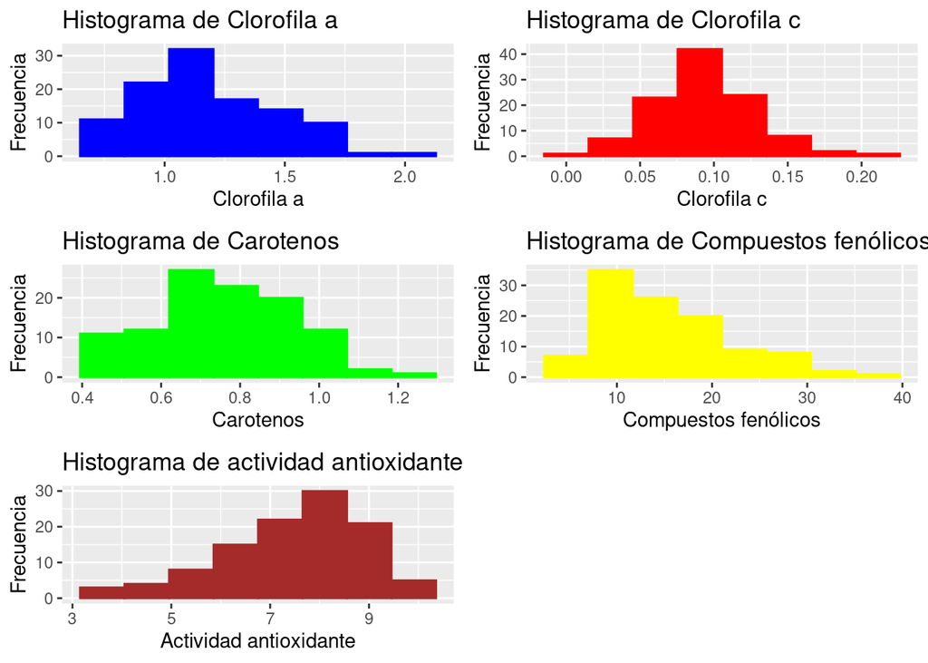

`r gridExtra::grid.arrange(p6, p7, p8, p9, ncol = 2)`

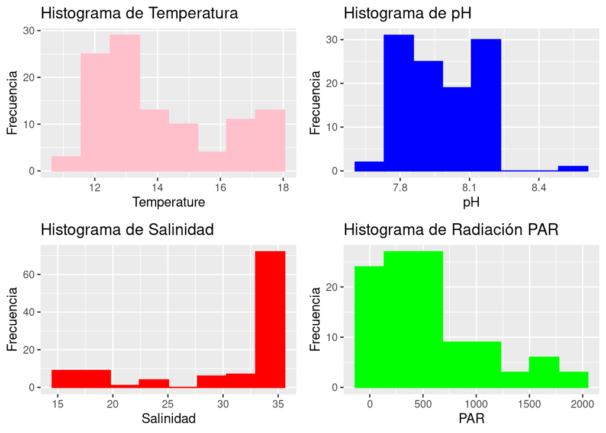

## 4. Datos balanceados y tablas de frecuencia

** Los datos estan balanceados

`r str(Datos_Proyecto)`

`## tibble [108 × 11] (S3: tbl_df/tbl/data.frame) ## $ Seasons : Factor w/ 4 levels "Autumn","Spring",..: 1 1 1 1 1 1 1 1 1 1 ... ## $ time : Factor w/ 3 levels "day 1","day 2",..: 1 1 1 1 1 1 1 1 1 2 ... ## $ Chla : num [1:108] 1.04 1.6 1.52 1.48 1.14 ... ## $ Chlc : num [1:108] 0.095 0.155 0.143 0.152 0.108 0.115 0.148 0.105 0.102 0.134 ... ## $ Car : num [1:108] 0.605 0.954 0.931 0.905 0.694 0.752 0.884 0.659 0.62 0.937 ... ## $ PC : num [1:108] 9.12 13.87 15.83 19.89 19.81 ... ## $ DPPH : num [1:108] 7.58 6.08 7.81 7.02 7.2 ... ## $ Temperature: num [1:108] 12.3 12.3 12.3 12.3 12.3 ... ## $ pH : num [1:108] 7.84 7.84 7.84 7.85 7.85 7.85 7.88 7.88 7.88 7.84 ... ## $ Salinity : num [1:108] 33.7 33.7 33.7 17.9 17.9 ... ## $ PAR : num [1:108] 594 594 594 1563 1563 ...`

`r knitr::kable(table(Datos_Proyecto$Seasons, Datos_Proyecto$time), caption = "Tabla de contingencia")`

Table: Tabla de contingencia

[output not shown]

## 5. Relación entre variables cuantitativas y factores

`r summary(Datos_Proyecto)`

`## Seasons time Chla Chlc Car ## Autumn:27 day 1:36 Min. :0.6730 Min. :0.01000 Min. :0.4190 ## Spring:27 day 2:36 1st Qu.:0.9888 1st Qu.:0.06775 1st Qu.:0.6240 ## Summer:27 day 3:36 Median :1.1660 Median :0.09500 Median :0.7520 ## Winter:27 Mean :1.1856 Mean :0.09365 Mean :0.7557 ## 3rd Qu.:1.3813 3rd Qu.:0.10975 3rd Qu.:0.8780 ## Max. :1.9690 Max. :0.22100 Max. :1.2080 ## PC DPPH Temperature pH ## Min. : 4.600 Min. : 3.792 Min. :11.54 Min. :7.620 ## 1st Qu.: 9.953 1st Qu.: 6.539 1st Qu.:12.47 1st Qu.:7.850 ## Median :13.815 Median : 7.769 Median :13.29 Median :7.960 ## Mean :15.153 Mean : 7.444 Mean :14.08 Mean :7.982 ## 3rd Qu.:18.990 3rd Qu.: 8.433 3rd Qu.:15.35 3rd Qu.:8.150 ## Max. :37.340 Max. :10.097 Max. :18.02 Max. :8.500 ## Salinity PAR ## Min. :16.44 Min. : 9.768 ## 1st Qu.:29.62 1st Qu.: 196.000 ## Median :34.10 Median : 525.793 ## Mean :30.49 Mean : 569.983 ## 3rd Qu.:34.63 3rd Qu.: 764.500 ## Max. :34.90 Max. :1921.000`

## 5. Graficas de correlación de variables continuas (pearson)

`r pairs.panels(Datos_Proyecto[,3:11], method = "pearson", hist.col = "blue", density = TRUE, font=4)`

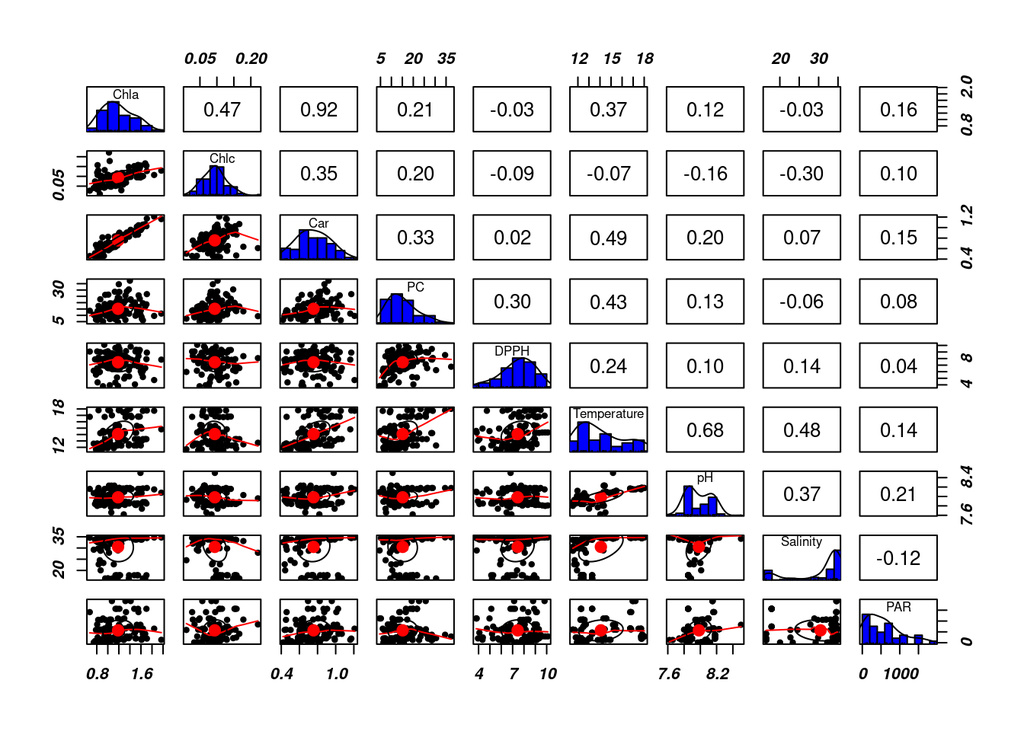

`r pairs.panels(Datos_Proyecto[,3:7], method = "pearson", hist.col = "blue", density = TRUE, font=2)`

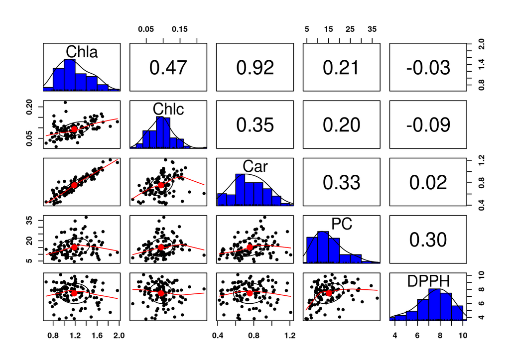

** Se muestra correlación entre las segundas 4 variables continuas

`r pairs.panels(Datos_Proyecto[,8:11], method = "pearson", hist.col = "blue", density = TRUE, font=2)`

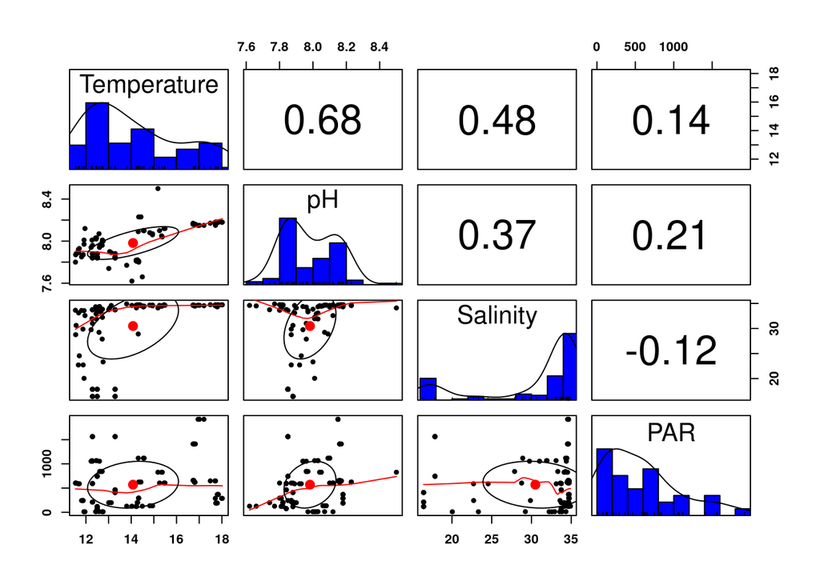

## 5. Relación entre variables continuas y factores (boxplot)

`r ggplot(Datos_Proyecto, aes(x= Seasons, y=Chla))+geom_boxplot(fill="olivedrab1")+labs(title = "BoxPlot", x= "Seasons", y= "Clorofila a")`

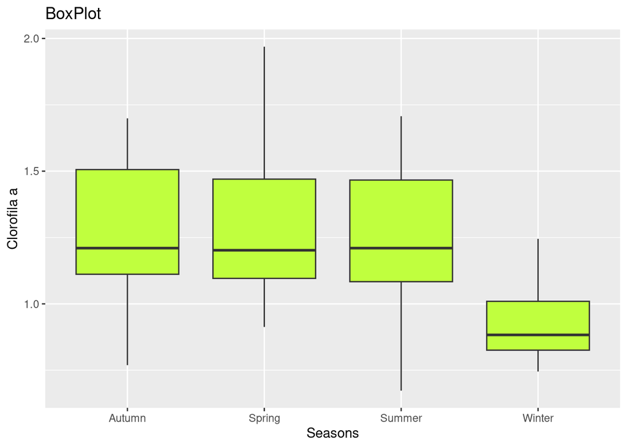

`r ggplot(Datos_Proyecto, aes(x= Seasons, y=Chlc))+geom_boxplot(fill="red")+labs(title = "BoxPlot", x= "Seasons", y= "Clorofila c")`

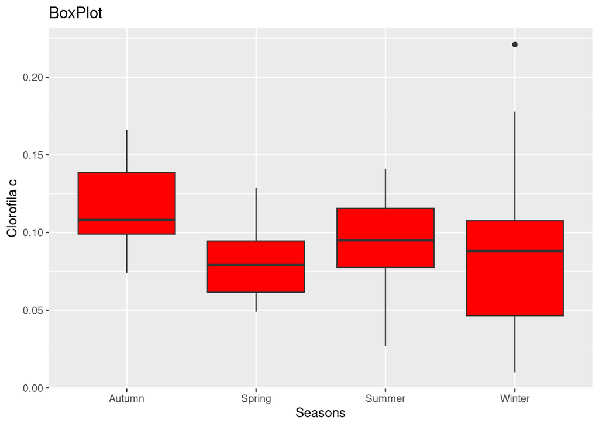

`r ggplot(Datos_Proyecto, aes(x= Seasons, y=Car))+geom_boxplot(fill="blue")+labs(title = "BoxPlot", x= "Seasons", y= "Carotenos")`

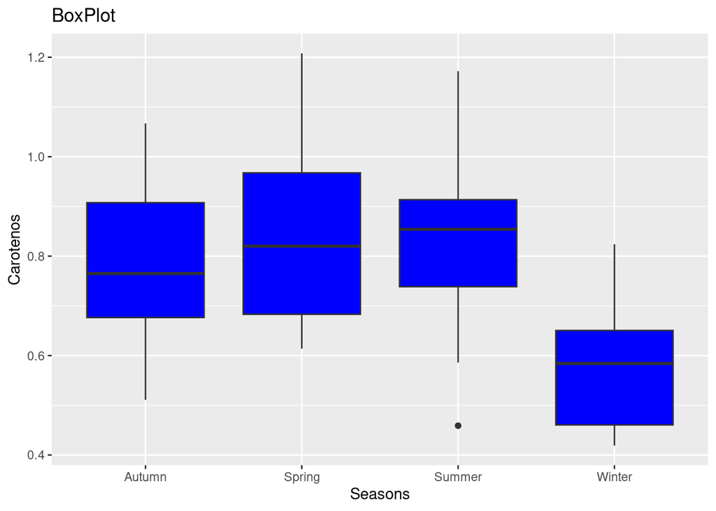

`r ggplot(Datos_Proyecto, aes(x= Seasons, y=PC))+geom_boxplot(fill="green")+labs(title = "BoxPlot", x= "Seasons", y= "Compuestos fenólicos")`

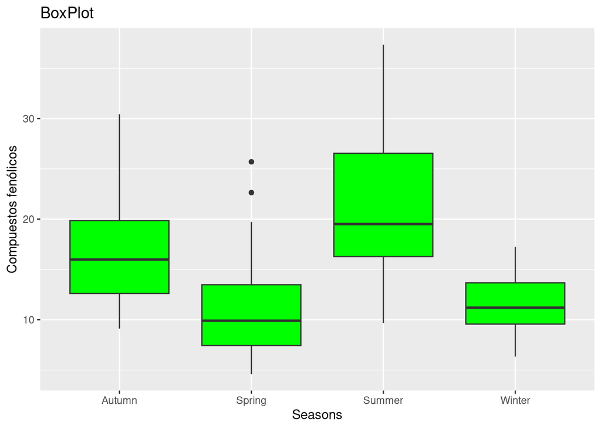

`r ggplot(Datos_Proyecto, aes(x= Seasons, y=DPPH))+geom_boxplot(fill="brown")+labs(title = "BoxPlot", x= "Seasons", y= "DPPH")`

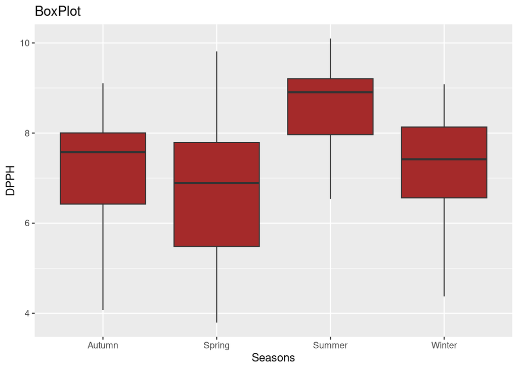

`r ggplot(Datos_Proyecto, aes(x= Seasons, y=Temperature))+geom_boxplot(fill="blue")+labs(title = "BoxPlot", x= "Seasons", y= "Temperatura")`

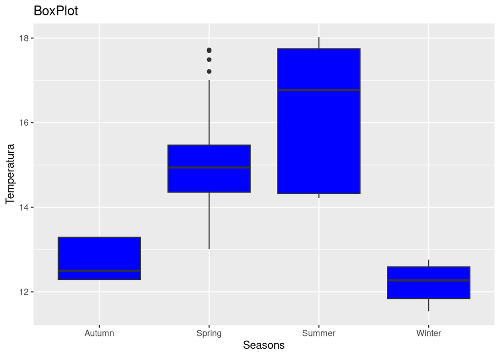

`r ggplot(Datos_Proyecto, aes(x= Seasons, y=pH))+geom_boxplot(fill="green")+labs(title = "BoxPlot", x= "Seasons", y= "pH")`

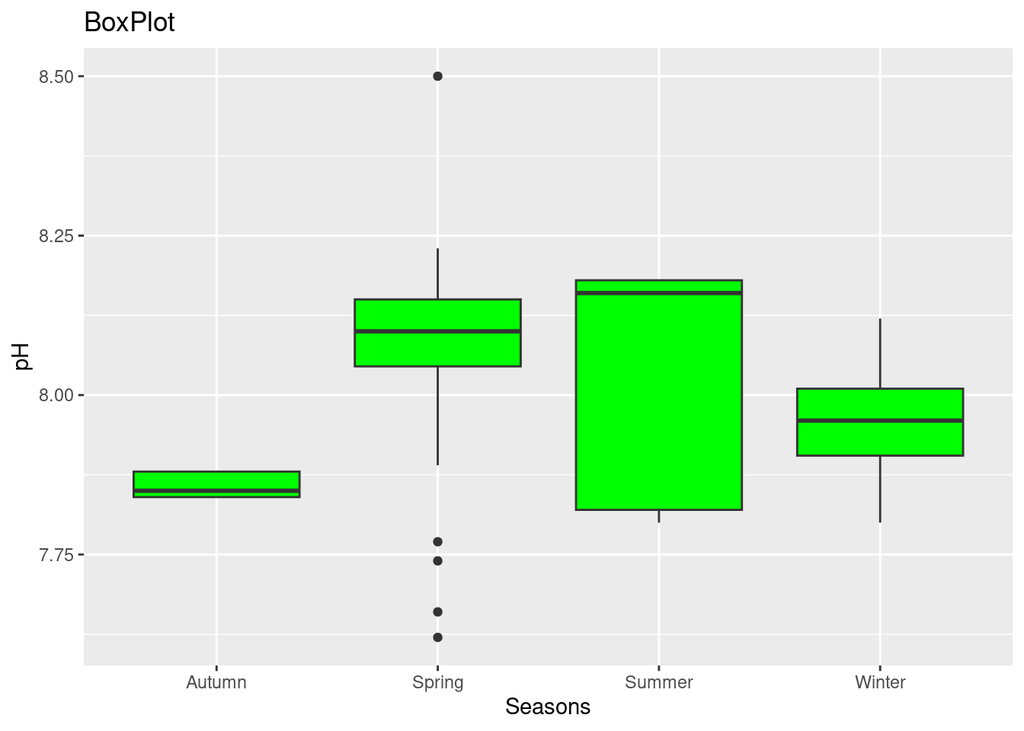

`r ggplot(Datos_Proyecto, aes(x= Seasons, y=Salinity))+geom_boxplot(fill="brown")+labs(title = "BoxPlot", x= "Seasons", y= "Salinity")`

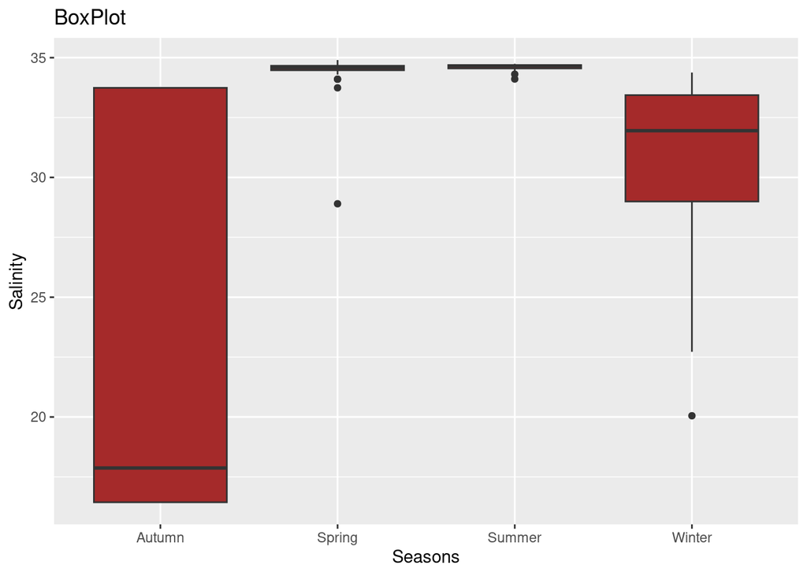

`r ggplot(Datos_Proyecto, aes(x= Seasons, y=PAR))+geom_boxplot(fill="yellow")+labs(title = "BoxPlot", x= "Seasons", y= "Radiación PAR")`

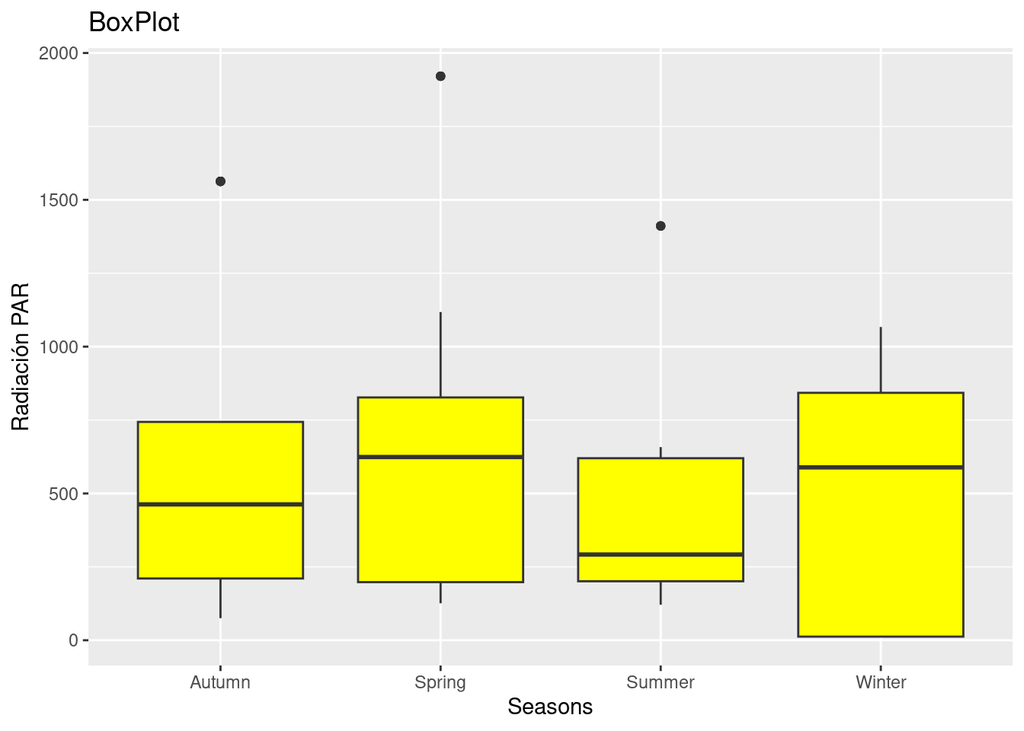

## 6. Identificación si existen errores, datos faltantes o error atípico